UPDATE: 2023-05-04 02:46:38

# はじめに

Marketing Mix Modeling(MMM)のシリーズでは、Meta社(Facebook)が開発したRobynパッケージのドキュメントをなぞりながら、MMMを理解するために必要な知識を整理し、RでMMMを実行するまでをまとめている。基本的には下記の公式ドキュメントを参考にしている。

- Robyn

## Adstock

AdstockはTVCMをもとに考えるとわかりやすい。TVCMは見たからと言って、すぐに購買につながるわけではなく、数日後、数週間後、数カ月後に再想起することで購買につなげる力があったりする。この性質があると仮定できそうなのに、データ上、支出の数字と購買金額は、同じ日に記録されるわけでもなく、別の日の売上に含まれてしまう。つまり、このようなデータ生成過程を考慮せず、モデリングを行うと、精度が高いモデルが構築できない。そのため、TVCMの支出を引き伸ばす、つまりAdstockすることで、変数を変換し、モデルの精度向上を目指す変換の方法。一番シンプルなGeometric Simple Decay Modelは下記の方法で変換する。

$$y_{t} = x_{t} + \lambda y_{t-1}$$
他にも、Geometric Log Decay ModelやDelayed Simple Decay Modelなどもある。詳しくは[こちらの記事](https://medium.com/@kyliefu/implementation-of-the-advertising-adstock-theory-in-r-62c2cc4b82fd)が参考になる。Robynでは基本的なAdstock変換だけではなく、ワイブル分布を利用したAdstock変換も利用できるため、広告の性質に合わせて、Adstock変換を行うことで、より現実に沿ったモデル構築ができる。

## Diminishing returns(Saturation)

広告の出稿量を増やすと、広告が到達するユーザーは増加して、需要も伴って増加しそうだが、広告の露出と売上は比例しない、という概念がDiminishing returns。広告を出せば出すだけ売上があがるわけでもなく、いつかは飽和するということ。

この関係を表すために、Adstock変換された値にパラメタを乗じることで、飽和する様子を表すことができる。Robynでの変換方法はドキュメントをみるとわかるが、もう少し複雑なので、下記の式ではなく、Hill関数を利用している。

$$DiminishingReturns_{t} = Adstock \ y_{t}^{\gamma}$$

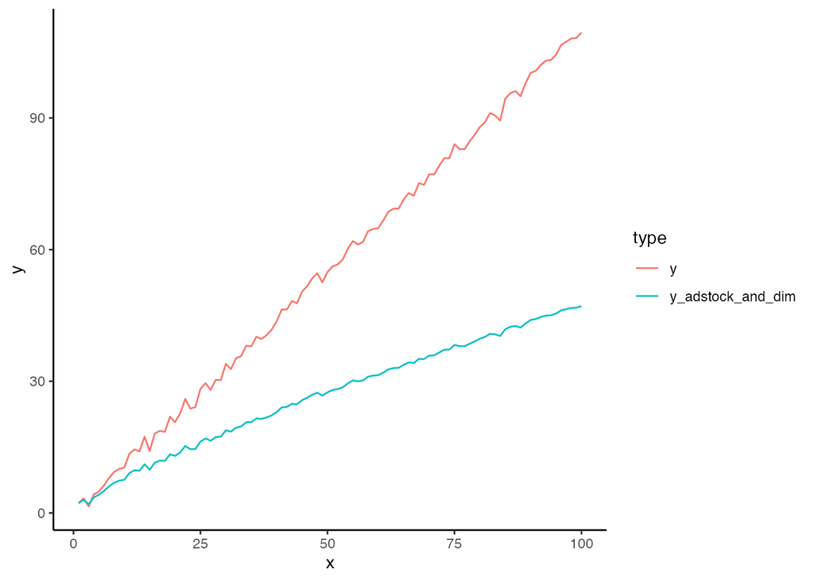

```r
library(tidyverse)
set.seed(1989)
x <- 1:100
y <- 1.1 * x + rnorm(n = length(x))


GeometricAdstock_and_DiminishingReturn <- function(x, lambda, gamma){
  res <- vector(mode = 'numeric', length = length(x))
  res[1] <- x[1]
  for (i in 2:length(x)) {
    res[i] <- (res[i-1]*lambda + x[i])^gamma
  }

  return(res)
}

y_adstock_and_dim <- GeometricAdstock_and_DiminishingReturn(y, 0.3, 0.8)
tibble(x, y, y_adstock_and_dim) %>%
  pivot_longer(
    cols = -x,
    names_to = 'type',
    values_to = 'y'
  ) %>%
  ggplot(aes(x, y, col = type)) +
  geom_line() +
  theme_classic()
```

RobynではspendとExposureの関係性を表現する際に、Hill equationによって変換が行われる。

$$x_{saturated_{i,j}} =
\frac{x_{adstocked_{i,j}}^{\alpha}}{x_{adstocked_{i,j}}^{\alpha} +
\gamma^{\alpha}}$$

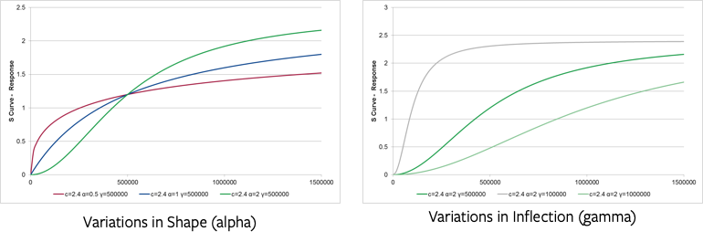

Diminishing returns

これは「TVCM支出(spend)とGRP(Exposure)」、「Facebook支出(spend)とインプレッション(Exposure)」などの支出と露出の関係を表現するためのもので、支出すれば最初はインプレッションがでやすいが、支出し続けると、インプレッションが頭打ちになるという関係を表している。

Robynを実行すると、Michaelis-Menten変換を行ったという旨の警告がでる。これはおそらくだが、Hillの式にはHill係数が含まれており、Hill係数が1の場合、Hillの式はMichaelis–Menten式に一致するからだと思われる。ただ、細かい部分の実装までは追えていないので、誤っている可能性がある。Hill equationやMichaelis-Mentenについては、下記を参考にした。

- [Hill Equation - Interactive Graph](https://www.physiologyweb.com/calculators/hill_equation_interactive_graph.html)

> If the Hill coefficient is equal to 1 (n = 1), the Hill equation is reduced to its simpler form known as the Michaelis-Menten equation.
- http://enzyme13.bt.a.u-tokyo.ac.jp/enzyme-kinetics-by-R.html

## モデリング

ここからは、簡単ではあるが変換を行うと回帰モデルのR2乗が増加するかを確認する。あてはまりの良さを表すR2乗で良いのか、という疑問を持つかもしれないが、簡単に調べるだけなので良しとする。本来であれば、時系列クロスバリデーション、Ridge回帰、Nevergradで多目的最適化を行って、変換が有効かどうかを調べるのがよいと思うが、それはRobynパッケージを使えば実行できるので、ここでは簡単に調べるだけにしておく。

まずは変換せずにモデルを構築するとR2乗は0.52となった。

```r
df <- read_csv('~/Desktop/adstock.csv')
fit_normal <- summary(lm(sales ~ youtube + facebook, data = df))
fit_normal$adj.r.squared
```

```
## [1] 0.5249186
```

次はAdstock変換とDiminishing returnsを考慮した変数を利用してモデルを構築する。R2乗は0.63となった。無変換の値よりも当てはまりが良くなっている。

```r
fit_adstock <- summary(lm(sales ~
             GeometricAdstock_and_DiminishingReturn(youtube, 0.5, 1) +
             GeometricAdstock_and_DiminishingReturn(facebook, 0.5, 0.9),
           data = df)
        )
fit_adstock$adj.r.squared
```

```
## [1] 0.6394171
```

ここで問題となるのが、変換の際のパラメタが決め打ちである点。これを非線形最小二乗法で最適化することで、より当てはまりが良くなるかを確認する。

```r
library(minpack.lm)

fit_nls1 <- nlsLM(
  data = df,
  sales ~ alpha +
    beta1 * GeometricAdstock_and_DiminishingReturn(youtube, lambda1, gamma1) +
    beta2 * GeometricAdstock_and_DiminishingReturn(facebook, lambda2, gamma2),
  start = c(
    alpha = fit_adstock$coefficients[1],
    beta1 = fit_adstock$coefficients[2],
    beta2 = fit_adstock$coefficients[3],
    lambda1 = 0.1,
    gamma1 = 0.1,
    lambda2 = 0.1,
    gamma2 = 0.1
  ),
  lower = c(-Inf, -Inf, -Inf, 0, 0, 0, 0),
  control = nls.control(maxiter = 5000)
)


fit_adstock_finalize <-
  lm(
    sales ~
      GeometricAdstock_and_DiminishingReturn(youtube, fit_nls1$m$getPars()[4], fit_nls1$m$getPars()[5]) +
      GeometricAdstock_and_DiminishingReturn(facebook, fit_nls1$m$getPars()[6], fit_nls1$m$getPars()[7]),
    data = df
  )

fit_nls1$m$getPars()
```

```
##     alpha     beta1     beta2   lambda1    gamma1   lambda2    gamma2
## 0.1505591 0.6325461 0.6748594 0.7595052 0.8902439 0.4377238 0.8797812
```

実行結果を確認すると0.65となって少し当てはまりをよくできた。

```r
summary(fit_adstock_finalize)$adj.r.squared
```

```
## [1] 0.659631
```

観測値と予測値もプロットして確認しておく。

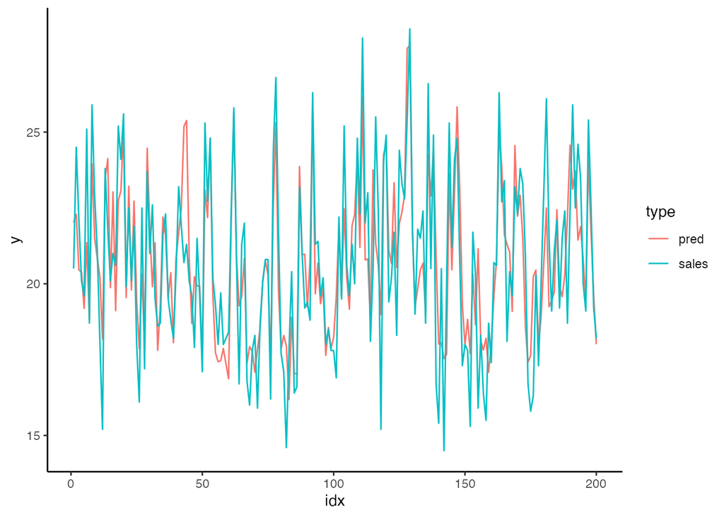

```r
df %>%
  bind_cols(idx = 1:200, pred = predict(fit_adstock_finalize, newdata = df)) %>%
  select(idx, sales, pred) %>%
  pivot_longer(
    cols = -idx,
    names_to = 'type',
    values_to = 'y'
  ) %>%
  ggplot(aes(idx, y, col = type)) +
  geom_line(size = 0.5) +
  theme_classic()
```

## おまけ: 再検証

Ridge回帰と時系列クロスバリデーションを使って、Adstock変換とDiminishing returnsを考慮することによるモデル精度の向上をRMESをもとに再検証する。まずは何も考慮しなかった場合、RMSEは2.28となった。

```r
library(tidymodels)

df_train <- df[1:180,]
df_test <- df[181:200,]

df_folds <- df_train %>%
  rolling_origin(
    initial = 120,
    assess = 20,
    skip = 9,
    cumulative = FALSE
  )
ridge_recipe <-
  recipe(formula = sales ~ ., data = df_train)

ridge_spec <-
  linear_reg(penalty = tune(), mixture = 0) %>%
  set_mode("regression") %>%
  set_engine("glmnet")
ridge_workflow <- workflow() %>%
  add_recipe(ridge_recipe) %>%
  add_model(ridge_spec)


penalty_grid <- grid_regular(penalty(range = c(-5, 5)), levels = 100)
tune_res <- tune_grid(
  ridge_workflow,
  resamples = df_folds,
  grid = penalty_grid
)
# autoplot(tune_res)
# collect_metrics(tune_res) %>%
#   filter(.metric == 'rmse')

best_penalty <- select_best(tune_res, metric = "rmse")
ridge_final <- finalize_workflow(ridge_workflow, best_penalty)
ridge_final_fit <- fit(ridge_final, data = df_train)

augment(ridge_final_fit, new_data = df_test) %>%
  rmse(truth = sales, estimate = .pred)
```

```
## # A tibble: 1 × 3
##   .metric .estimator .estimate
##   <chr>   <chr>          <dbl>
## 1 rmse    standard        2.28
```

次はAdstock変換とDiminishing returnsを考慮した場合は、RMSEは1.91となった。

```r
df$youtube <- GeometricAdstock_and_DiminishingReturn(df$youtube, 0.7595052, 0.8902439)
df$facebook <- GeometricAdstock_and_DiminishingReturn(df$facebook, 0.4377238, 0.8797812)

df_train2 <- df[1:180,]
df_test2 <- df[181:200,]

df_folds2 <- df_train2 %>%
  rolling_origin(
    initial = 120,
    assess = 20,
    skip = 9,
    cumulative = FALSE
  )

tune_res <- tune_grid(
  ridge_workflow,
  resamples = df_folds2,
  grid = penalty_grid
)
# autoplot(tune_res)

best_penalty <- select_best(tune_res, metric = "rmse")
ridge_final <- finalize_workflow(ridge_workflow, best_penalty)
ridge_final_fit <- fit(ridge_final, data = df_train2)
augment(ridge_final_fit, new_data = df_test2) %>%
  rmse(truth = sales, estimate = .pred)
```

```
## # A tibble: 1 × 3
##   .metric .estimator .estimate
##   <chr>   <chr>          <dbl>
## 1 rmse    standard        1.91
```

このように、Adstock変換とDiminishing returnsを考慮するだけでモデルの精度を向上させることができた。

## 参考文献

- [Robyn Features](https://facebookexperimental.github.io/Robyn/docs/features)
- [Robyn Analysts guide to MMM](https://facebookexperimental.github.io/Robyn/docs/analysts-guide-to-MMM)
- [Robyn R demo](https://github.com/facebookexperimental/Robyn/blob/main/demo/demo.R)
- [統計コンサルの議事メモ](https://ushi-goroshi.hatenablog.com/search?q=mmm)
- [Using R to Build a Simple Marketing Mix Model (MMM) and Make Predictions](https://towardsdatascience.com/building-a-marketing-mix-model-in-r-3a7004d21239)
- [Media-Mix-Model-Modified/メディアミックスモデルの利点と限界](https://speakerdeck.com/ktgrstsh/medeiamitukusumoderufalseli-dian-toxian-jie)